# 1. Importing libraries and loading data

These libraries are used for data handling (pandas, numpy), visualization (matplotlib, seaborn, plotly, missingno), and machine learning tasks (scikit-learn). They help in preprocessing, model building, evaluation, and optimization, making data analysis and predictive modeling efficient.

```python
# Import necessary libraries
import pandas as pd  # For data manipulation and analysis
import numpy as np  # For numerical computations
import missingno as msno  # For visualizing missing values
import matplotlib.pyplot as plt  # For static data visualization
import seaborn as sns  # For enhanced data visualization

# Import Plotly for interactive visualizations
import plotly.express as px
import plotly.graph_objects as go
from plotly.subplots import make_subplots

# Suppress warnings to keep the output clean
import warnings
warnings.filterwarnings('ignore')

# Import preprocessing modules from scikit-learn
from sklearn.preprocessing import StandardScaler  # For feature scaling
from sklearn.preprocessing import LabelEncoder  # For encoding categorical variables

# Import machine learning models
from sklearn.tree import DecisionTreeClassifier  # Decision Tree model
from sklearn.ensemble import RandomForestClassifier  # Random Forest model
from sklearn.naive_bayes import GaussianNB  # Naive Bayes classifier
from sklearn.neighbors import KNeighborsClassifier  # K-Nearest Neighbors classifier
from sklearn.linear_model import LogisticRegression  # Logistic Regression model

# Import tools for splitting data and model evaluation
from sklearn.model_selection import train_test_split  # Splitting dataset into train and test sets
from sklearn.metrics import accuracy_score  # For measuring model accuracy
from sklearn import metrics  # Various performance metrics
from sklearn.metrics import roc_curve  # Receiver Operating Characteristic (ROC) curve
from sklearn.metrics import recall_score, confusion_matrix, precision_score, f1_score, accuracy_score, classification_report, roc_auc_score  # Additional model evaluation metrics

# Import GridSearchCV for hyperparameter tuning
from sklearn.model_selection import GridSearchCV
```

# Data Visualization and Exploration

Below code allows you to access and work with files stored in your Google Drive directly from Google Colab

```python
# Import the drive module from Google Colab to access Google Drive
from google.colab import drive

# Mount Google Drive to the Colab environment for file access
drive.mount('/content/drive')
```

Read a CSV file from Google Drive into a Pandas DataFrame for analysis. It then displays the first five rows to check if the data is loaded correctly and to get a quick overview.

```python
# Reading the dataset from a CSV file into a Pandas DataFrame
#Sanity check of data loaded
file_path = r"/content/drive/MyDrive/Telco-Dataset.csv"

# Read the CSV file into a DataFrame
df = pd.read_csv(file_path)
# Displaying the first 5 rows of the dataset to get a quick overview of the data
df.head()
```

|  | customerID | gender | SeniorCitizen | Partner | Dependents | tenure | PhoneService | MultipleLines | InternetService | OnlineSecurity | ... | DeviceProtection | TechSupport | StreamingTV | StreamingMovies | Contract | PaperlessBilling | PaymentMethod | MonthlyCharges | TotalCharges | Churn |
| --- | --- | --- | --- | --- | --- | --- | --- | --- | --- | --- | --- | --- | --- | --- | --- | --- | --- | --- | --- | --- | --- |
| 0 | 7590-VHVEG | Female | 0 | Yes | No | 1 | No | No phone service | DSL | No | ... | No | No | No | No | Month-to-month | Yes | Electronic check | 29.85 | 29.85 | No |
| 1 | 5575-GNVDE | Male | 0 | No | No | 34 | Yes | No | DSL | Yes | ... | Yes | No | No | No | One year | No | Mailed check | 56.95 | 1889.5 | No |
| 2 | 3668-QPYBK | Male | 0 | No | No | 2 | Yes | No | DSL | Yes | ... | No | No | No | No | Month-to-month | Yes | Mailed check | 53.85 | 108.15 | Yes |
| 3 | 7795-CFOCW | Male | 0 | No | No | 45 | No | No phone service | DSL | Yes | ... | Yes | Yes | No | No | One year | No | Bank transfer (automatic) | 42.30 | 1840.75 | No |
| 4 | 9237-HQITU | Female | 0 | No | No | 2 | Yes | No | Fiber optic | No | ... | No | No | No | No | Month-to-month | Yes | Electronic check | 70.70 | 151.65 | Yes |

5 rows × 21 columns

# Dataset Description and Shape

provide a statistical summary of the dataset using describe() and displays the number of rows and columns using shape. It helps in understanding the data distribution and structure.

```python
# Description of the dataset
print("Description of dataset:")
print(df.describe())

# Shape of the dataset
print("Shape of dataset:", df.shape)
```

```
Description of dataset:
       SeniorCitizen       tenure  MonthlyCharges
count    7043.000000  7043.000000     7043.000000
mean        0.162147    32.371149       64.761692
std         0.368612    24.559481       30.090047
min         0.000000     0.000000       18.250000
25%         0.000000     9.000000       35.500000
50%         0.000000    29.000000       70.350000
75%         0.000000    55.000000       89.850000
max         1.000000    72.000000      118.750000
Shape of dataset: (7043, 21)
```

Display the DataFrame’s structure, including column names, data types, and non-null counts. It helps in understanding data types and identifying missing values.

```python
# Displaying DataFrame information
df.info()
```

```
<class 'pandas.core.frame.DataFrame'>
RangeIndex: 7043 entries, 0 to 7042
Data columns (total 21 columns):
 #   Column            Non-Null Count  Dtype
---  ------            --------------  -----
 0   customerID        7043 non-null   object
 1   gender            7043 non-null   object
 2   SeniorCitizen     7043 non-null   int64
 3   Partner           7043 non-null   object
 4   Dependents        7043 non-null   object
 5   tenure            7043 non-null   int64
 6   PhoneService      7043 non-null   object
 7   MultipleLines     7043 non-null   object
 8   InternetService   7043 non-null   object
 9   OnlineSecurity    7043 non-null   object
 10  OnlineBackup      7043 non-null   object
 11  DeviceProtection  7043 non-null   object
 12  TechSupport       7043 non-null   object
 13  StreamingTV       7043 non-null   object
 14  StreamingMovies   7043 non-null   object
 15  Contract          7043 non-null   object
 16  PaperlessBilling  7043 non-null   object
 17  PaymentMethod     7043 non-null   object
 18  MonthlyCharges    7043 non-null   float64
 19  TotalCharges      7043 non-null   object
 20  Churn             7043 non-null   object
dtypes: float64(1), int64(2), object(18)
memory usage: 1.1+ MB
```

Show the data type of each column, helping to identify numerical, categorical, or object data types.

```python
# Display the data types of each column in the DataFrame
df.dtypes
```

|  | 0 |
| --- | --- |
| customerID | object |
| gender | object |
| SeniorCitizen | int64 |
| Partner | object |
| Dependents | object |
| tenure | int64 |
| PhoneService | object |
| MultipleLines | object |
| InternetService | object |
| OnlineSecurity | object |
| OnlineBackup | object |
| DeviceProtection | object |
| TechSupport | object |
| StreamingTV | object |
| StreamingMovies | object |
| Contract | object |
| PaperlessBilling | object |
| PaymentMethod | object |
| MonthlyCharges | float64 |
| TotalCharges | object |
| Churn | object |

**dtype:** object

Visualize missing values in the dataset. The matrix plot helps identify patterns of missing data for better visibility.

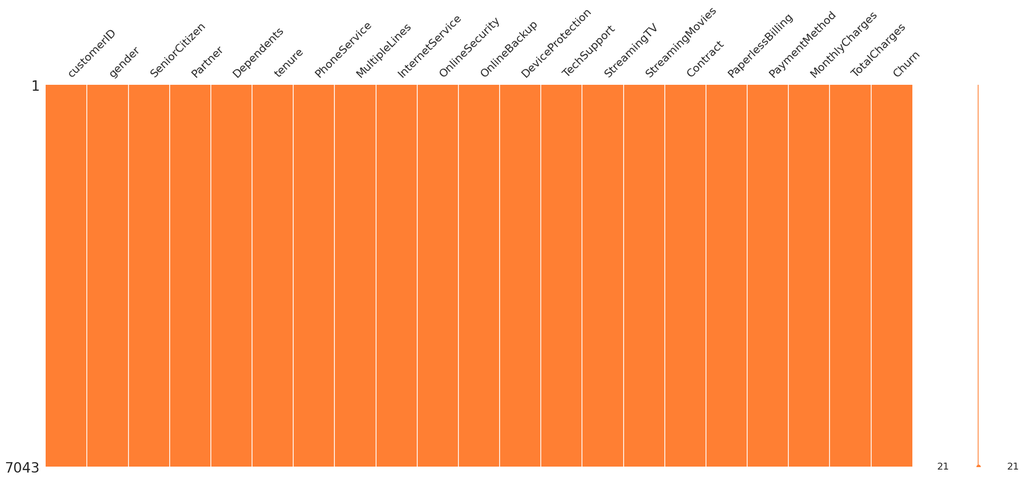

```python
# Set seaborn style for better visualization
sns.set_style("darkgrid")  # Adds a subtle grid background for readability

# Visualizing missing values as a matrix with custom color
msno.matrix(df, color=(1.0, 0.5, 0.2))
```

Using this matrix we can very quickly find the pattern of missingness in the dataset.From the above visualisation we can observe that it has no peculiar pattern that stands out. In fact there is no missing data.

The heatmap visually represents the correlation between numerical features in the dataset.

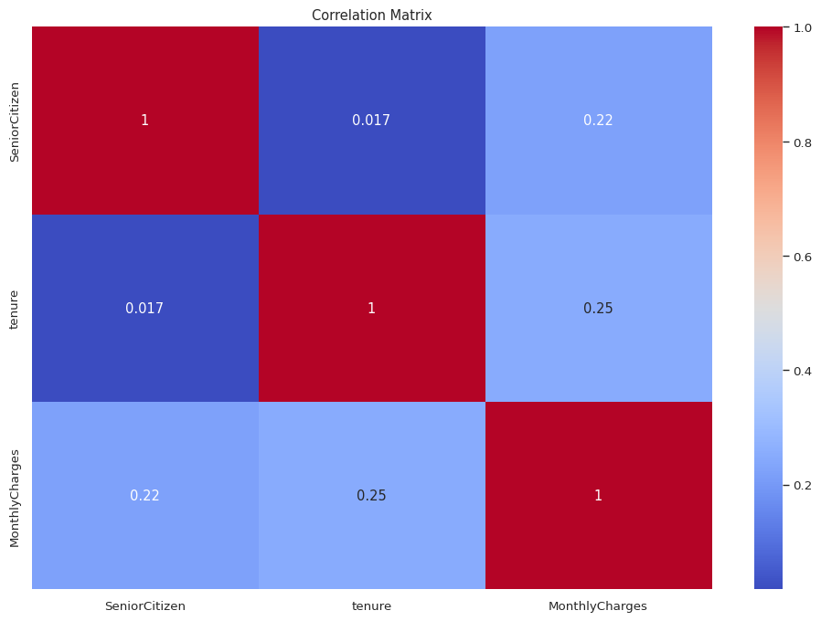

```python
# Correlation Heatmap (For numeric features)
numeric_df = df.select_dtypes(include=[np.number])
plt.figure(figsize=(12, 8))
sns.heatmap(numeric_df.corr(), annot=True, cmap='coolwarm')
plt.title('Correlation Matrix')
plt.show()
```

# Data Manipulation

Remove the 'customerID' column as it is a unique identifier and does not contribute to data analysis or modeling.

```python
# Drop the 'customerID' column as it is not useful for analysis or modeling
df = df.drop(['customerID'], axis=1)

# Display the first 5 rows of the updated DataFrame to confirm the change
df.head()
```

|  | gender | SeniorCitizen | Partner | Dependents | tenure | PhoneService | MultipleLines | InternetService | OnlineSecurity | OnlineBackup | DeviceProtection | TechSupport | StreamingTV | StreamingMovies | Contract | PaperlessBilling | PaymentMethod | MonthlyCharges | TotalCharges | Churn |
| --- | --- | --- | --- | --- | --- | --- | --- | --- | --- | --- | --- | --- | --- | --- | --- | --- | --- | --- | --- | --- |
| 0 | Female | 0 | Yes | No | 1 | No | No phone service | DSL | No | Yes | No | No | No | No | Month-to-month | Yes | Electronic check | 29.85 | 29.85 | No |
| 1 | Male | 0 | No | No | 34 | Yes | No | DSL | Yes | No | Yes | No | No | No | One year | No | Mailed check | 56.95 | 1889.5 | No |
| 2 | Male | 0 | No | No | 2 | Yes | No | DSL | Yes | Yes | No | No | No | No | Month-to-month | Yes | Mailed check | 53.85 | 108.15 | Yes |
| 3 | Male | 0 | No | No | 45 | No | No phone service | DSL | Yes | No | Yes | Yes | No | No | One year | No | Bank transfer (automatic) | 42.30 | 1840.75 | No |
| 4 | Female | 0 | No | No | 2 | Yes | No | Fiber optic | No | No | No | No | No | No | Month-to-month | Yes | Electronic check | 70.70 | 151.65 | Yes |

Convert the "TotalCharges" column to a numeric type, replacing any non-numeric values with NaN. Then count and display the total number of missing values in each column, helping identify data that may need cleaning.

```python
# Convert the 'TotalCharges' column to numeric, setting non-numeric values to NaN.
df['TotalCharges'] = pd.to_numeric(df.TotalCharges, errors='coerce')

# Count and display the number of missing values in each column.
df.isnull().sum()
```

|  | 0 |
| --- | --- |
| gender | 0 |
| SeniorCitizen | 0 |
| Partner | 0 |
| Dependents | 0 |
| tenure | 0 |
| PhoneService | 0 |
| MultipleLines | 0 |
| InternetService | 0 |
| OnlineSecurity | 0 |
| OnlineBackup | 0 |
| DeviceProtection | 0 |
| TechSupport | 0 |
| StreamingTV | 0 |
| StreamingMovies | 0 |
| Contract | 0 |
| PaperlessBilling | 0 |
| PaymentMethod | 0 |
| MonthlyCharges | 0 |
| TotalCharges | 11 |
| Churn | 0 |

**dtype:** int64

The "TotalCharges" column has 11 missing values. Let's examine this data further.

```python
# Filter and display rows where 'TotalCharges' has missing values (NaN)
df[np.isnan(df['TotalCharges'])]
```

|  | gender | SeniorCitizen | Partner | Dependents | tenure | PhoneService | MultipleLines | InternetService | OnlineSecurity | OnlineBackup | DeviceProtection | TechSupport | StreamingTV | StreamingMovies | Contract | PaperlessBilling | PaymentMethod | MonthlyCharges | TotalCharges | Churn |
| --- | --- | --- | --- | --- | --- | --- | --- | --- | --- | --- | --- | --- | --- | --- | --- | --- | --- | --- | --- | --- |
| 488 | Female | 0 | Yes | Yes | 0 | No | No phone service | DSL | Yes | No | Yes | Yes | Yes | No | Two year | Yes | Bank transfer (automatic) | 52.55 | NaN | No |
| 753 | Male | 0 | No | Yes | 0 | Yes | No | No | No internet service | No internet service | No internet service | No internet service | No internet service | No internet service | Two year | No | Mailed check | 20.25 | NaN | No |
| 936 | Female | 0 | Yes | Yes | 0 | Yes | No | DSL | Yes | Yes | Yes | No | Yes | Yes | Two year | No | Mailed check | 80.85 | NaN | No |
| 1082 | Male | 0 | Yes | Yes | 0 | Yes | Yes | No | No internet service | No internet service | No internet service | No internet service | No internet service | No internet service | Two year | No | Mailed check | 25.75 | NaN | No |
| 1340 | Female | 0 | Yes | Yes | 0 | No | No phone service | DSL | Yes | Yes | Yes | Yes | Yes | No | Two year | No | Credit card (automatic) | 56.05 | NaN | No |
| 3331 | Male | 0 | Yes | Yes | 0 | Yes | No | No | No internet service | No internet service | No internet service | No internet service | No internet service | No internet service | Two year | No | Mailed check | 19.85 | NaN | No |
| 3826 | Male | 0 | Yes | Yes | 0 | Yes | Yes | No | No internet service | No internet service | No internet service | No internet service | No internet service | No internet service | Two year | No | Mailed check | 25.35 | NaN | No |
| 4380 | Female | 0 | Yes | Yes | 0 | Yes | No | No | No internet service | No internet service | No internet service | No internet service | No internet service | No internet service | Two year | No | Mailed check | 20.00 | NaN | No |
| 5218 | Male | 0 | Yes | Yes | 0 | Yes | No | No | No internet service | No internet service | No internet service | No internet service | No internet service | No internet service | One year | Yes | Mailed check | 19.70 | NaN | No |
| 6670 | Female | 0 | Yes | Yes | 0 | Yes | Yes | DSL | No | Yes | Yes | Yes | Yes | No | Two year | No | Mailed check | 73.35 | NaN | No |
| 6754 | Male | 0 | No | Yes | 0 | Yes | Yes | DSL | Yes | Yes | No | Yes | No | No | Two year | Yes | Bank transfer (automatic) | 61.90 | NaN | No |

We can observe that the "Tenure" column is 0 for these entries, even though the "MonthlyCharges" column is not empty. Now, let's check if there are any other instances where the "Tenure" column has a value of 0.

```python
# Retrieve the index positions of rows where the 'tenure' column has a value of 0
df[df['tenure'] == 0].index

# This helps identify customers with zero tenure, which may indicate new sign-ups or potential data inconsistencies.
```

```
Index([488, 753, 936, 1082, 1340, 3331, 3826, 4380, 5218, 6670, 6754], dtype='int64')
```

There are no additional missing values in the "Tenure" column. Since only 11 rows have missing values, we can safely delete them without significantly impacting the dataset.

```python
# Drop rows where the 'tenure' column is 0, as these rows contain missing values in 'TotalCharges'
df.drop(labels=df[df['tenure'] == 0].index, axis=0, inplace=True)

# Verify that no rows with 'tenure' equal to 0 remain in the dataset
df[df['tenure'] == 0].index
```

```
Index([], dtype='int64')
```

To address the missing values in the "TotalCharges" column, I decided to fill them with the column's mean value.

```python
# Fill missing values in the DataFrame with the mean of the "TotalCharges" column
df.fillna(df["TotalCharges"].mean())

# This replaces NaN values in all columns, but primarily addresses missing values in "TotalCharges" by using its mean.
```

|  | gender | SeniorCitizen | Partner | Dependents | tenure | PhoneService | MultipleLines | InternetService | OnlineSecurity | OnlineBackup | DeviceProtection | TechSupport | StreamingTV | StreamingMovies | Contract | PaperlessBilling | PaymentMethod | MonthlyCharges | TotalCharges | Churn |
| --- | --- | --- | --- | --- | --- | --- | --- | --- | --- | --- | --- | --- | --- | --- | --- | --- | --- | --- | --- | --- |
| 0 | Female | 0 | Yes | No | 1 | No | No phone service | DSL | No | Yes | No | No | No | No | Month-to-month | Yes | Electronic check | 29.85 | 29.85 | No |
| 1 | Male | 0 | No | No | 34 | Yes | No | DSL | Yes | No | Yes | No | No | No | One year | No | Mailed check | 56.95 | 1889.50 | No |
| 2 | Male | 0 | No | No | 2 | Yes | No | DSL | Yes | Yes | No | No | No | No | Month-to-month | Yes | Mailed check | 53.85 | 108.15 | Yes |
| 3 | Male | 0 | No | No | 45 | No | No phone service | DSL | Yes | No | Yes | Yes | No | No | One year | No | Bank transfer (automatic) | 42.30 | 1840.75 | No |
| 4 | Female | 0 | No | No | 2 | Yes | No | Fiber optic | No | No | No | No | No | No | Month-to-month | Yes | Electronic check | 70.70 | 151.65 | Yes |
| ... | ... | ... | ... | ... | ... | ... | ... | ... | ... | ... | ... | ... | ... | ... | ... | ... | ... | ... | ... | ... |
| 7038 | Male | 0 | Yes | Yes | 24 | Yes | Yes | DSL | Yes | No | Yes | Yes | Yes | Yes | One year | Yes | Mailed check | 84.80 | 1990.50 | No |
| 7039 | Female | 0 | Yes | Yes | 72 | Yes | Yes | Fiber optic | No | Yes | Yes | No | Yes | Yes | One year | Yes | Credit card (automatic) | 103.20 | 7362.90 | No |
| 7040 | Female | 0 | Yes | Yes | 11 | No | No phone service | DSL | Yes | No | No | No | No | No | Month-to-month | Yes | Electronic check | 29.60 | 346.45 | No |
| 7041 | Male | 1 | Yes | No | 4 | Yes | Yes | Fiber optic | No | No | No | No | No | No | Month-to-month | Yes | Mailed check | 74.40 | 306.60 | Yes |
| 7042 | Male | 0 | No | No | 66 | Yes | No | Fiber optic | Yes | No | Yes | Yes | Yes | Yes | Two year | Yes | Bank transfer (automatic) | 105.65 | 6844.50 | No |

7032 rows × 20 columns

Now check for missing values in each column and returns the count. This helps verify if all missing values, especially in "TotalCharges," have been successfully filled.

```python
# Count and display the number of missing values in each column after filling missing values
df.isnull().sum()
```

|  | 0 |
| --- | --- |
| gender | 0 |
| SeniorCitizen | 0 |
| Partner | 0 |
| Dependents | 0 |
| tenure | 0 |
| PhoneService | 0 |
| MultipleLines | 0 |
| InternetService | 0 |
| OnlineSecurity | 0 |
| OnlineBackup | 0 |
| DeviceProtection | 0 |
| TechSupport | 0 |
| StreamingTV | 0 |
| StreamingMovies | 0 |
| Contract | 0 |
| PaperlessBilling | 0 |
| PaymentMethod | 0 |
| MonthlyCharges | 0 |
| TotalCharges | 0 |
| Churn | 0 |

**dtype:** int64

Converted the "SeniorCitizen" column from numerical values (0 and 1) to categorical labels ("No" and "Yes") and displayed the first five rows to confirm the changes.

```python
# Convert the 'SeniorCitizen' column from numerical values (0 and 1) to categorical labels ("No" and "Yes")
df["SeniorCitizen"] = df["SeniorCitizen"].map({0: "No", 1: "Yes"})

# Display the first five rows of the DataFrame to verify the changes
df.head()
```

|  | gender | SeniorCitizen | Partner | Dependents | tenure | PhoneService | MultipleLines | InternetService | OnlineSecurity | OnlineBackup | DeviceProtection | TechSupport | StreamingTV | StreamingMovies | Contract | PaperlessBilling | PaymentMethod | MonthlyCharges | TotalCharges | Churn |
| --- | --- | --- | --- | --- | --- | --- | --- | --- | --- | --- | --- | --- | --- | --- | --- | --- | --- | --- | --- | --- |
| 0 | Female | No | Yes | No | 1 | No | No phone service | DSL | No | Yes | No | No | No | No | Month-to-month | Yes | Electronic check | 29.85 | 29.85 | No |
| 1 | Male | No | No | No | 34 | Yes | No | DSL | Yes | No | Yes | No | No | No | One year | No | Mailed check | 56.95 | 1889.50 | No |
| 2 | Male | No | No | No | 2 | Yes | No | DSL | Yes | Yes | No | No | No | No | Month-to-month | Yes | Mailed check | 53.85 | 108.15 | Yes |
| 3 | Male | No | No | No | 45 | No | No phone service | DSL | Yes | No | Yes | Yes | No | No | One year | No | Bank transfer (automatic) | 42.30 | 1840.75 | No |
| 4 | Female | No | No | No | 2 | Yes | No | Fiber optic | No | No | No | No | No | No | Month-to-month | Yes | Electronic check | 70.70 | 151.65 | Yes |

Provide summary statistics for the "InternetService" column, including count, unique values, most frequent value (top), and its frequency (freq). This helps understand the distribution of categorical or boolean data in the column.

```python
# Generate descriptive statistics for the 'InternetService' column, which contains categorical or boolean data
df["InternetService"].describe(include=['object', 'bool'])
```

|  | InternetService |
| --- | --- |
| count | 7032 |
| unique | 3 |
| top | Fiber optic |
| freq | 3096 |

**dtype:** object

select numerical columns: "tenure," "MonthlyCharges," and "TotalCharges. Generate summary statistics, including count, mean, standard deviation, min, max, and quartiles, to get insights into the data distribution.

```python
# Define a list of numerical columns to analyze
numerical_cols = ['tenure', 'MonthlyCharges', 'TotalCharges']

# Generate summary statistics (count, mean, std, min, max, quartiles) for the selected numerical columns
df[numerical_cols].describe()
```

|  | tenure | MonthlyCharges | TotalCharges |
| --- | --- | --- | --- |
| count | 7032.000000 | 7032.000000 | 7032.000000 |
| mean | 32.421786 | 64.798208 | 2283.300441 |
| std | 24.545260 | 30.085974 | 2266.771362 |
| min | 1.000000 | 18.250000 | 18.800000 |
| 25% | 9.000000 | 35.587500 | 401.450000 |
| 50% | 29.000000 | 70.350000 | 1397.475000 |
| 75% | 55.000000 | 89.862500 | 3794.737500 |
| max | 72.000000 | 118.750000 | 8684.800000 |

# 3.Data Visualization

With below two donut-style pie charts we can visualize gender and churn distributions and also it customizes labels, percentages, and annotations to enhance readability, making it easier to compare gender proportions and churn rates side by side.From the below data we can easy see that **26.6%** of customers have churned and switched to another provider and the customer base consists of **49.5%** females and **50.5%** males.

```python
# Define labels for gender and churn categories
g_labels = ['Male', 'Female']
c_labels = ['No', 'Yes']

# Define custom colors
gender_colors = ['#1f77b4', '#ff7f0e']  # Blue for Male, Orange for Female
churn_colors = ['#2ca02c', '#d62728']  # Green for No, Red for Yes

# Create subplots with 'domain' type for pie charts
fig = make_subplots(rows=1, cols=2, specs=[[{'type':'domain'}, {'type':'domain'}]])

# Add pie chart for Gender distribution with custom colors
fig.add_trace(go.Pie(labels=g_labels, values=df['gender'].value_counts(), name="Gender",
                     marker=dict(colors=gender_colors)), 1, 1)

# Add pie chart for Churn distribution with custom colors
fig.add_trace(go.Pie(labels=c_labels, values=df['Churn'].value_counts(), name="Churn",
                     marker=dict(colors=churn_colors)), 1, 2)

# Customize the pie charts to have a donut-like appearance
fig.update_traces(hole=.4, hoverinfo="label+percent+name", textfont_size=16)

# Update layout with title and annotations for clarity
fig.update_layout(
    title_text="Gender and Churn Distributions",
    # Add labels in the center of the donut charts
    annotations=[dict(text='Gender', x=0.16, y=0.5, font_size=20, showarrow=False),
                 dict(text='Churn', x=0.84, y=0.5, font_size=20, showarrow=False)]
)

# Display the pie charts
fig.show()
```

[interactive chart not shown]

Filter customers who did not churn (Churn == "No") and groups them by gender and counts the number of non-churned customers in each gender category which help to analyze retention trends.

```python
# Count the number of non-churned customers ("No") grouped by gender
df["Churn"][df["Churn"] == "No"].groupby(by=df["gender"]).count()
```

| gender | Churn |
| --- | --- |
| Female | 2544 |
| Male | 2619 |

**dtype:** int64

Now filter rows where "Churn" is "Yes", then groups by "gender" and counts occurrences in the "Churn" column. Below is the data for churn count per gender

```python
#churn count per gender
df[df["Churn"] == "Yes"]["gender"].value_counts()
```

| gender | count |
| --- | --- |
| Female | 939 |
| Male | 930 |

**dtype:** int64

Create a donut chart visualizing churn distribution (Yes/No) and overlays a second pie chart showing gender distribution within each churn category.Data shows that there is negligible difference in the percentage or count of customers who switched service providers, as both genders exhibited similar behavior when migrating to another provider or firm.

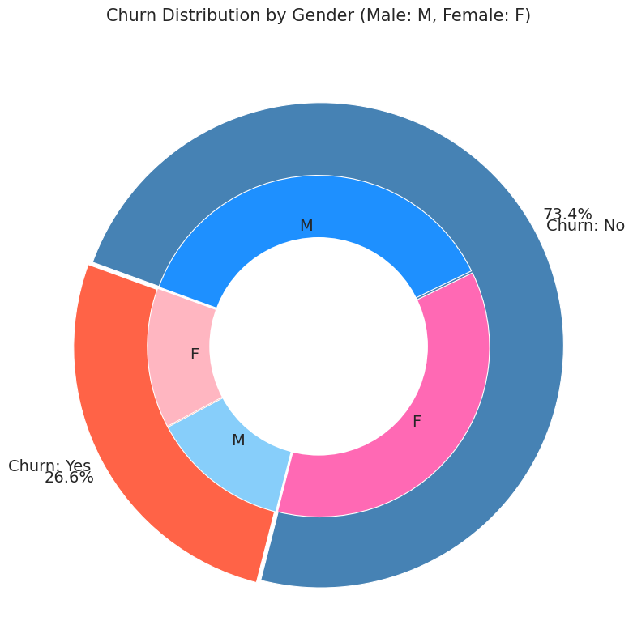

```python
# Define main pie chart data
labels = ["Churn: Yes", "Churn: No"]
values = [1869, 5163]
colors = ['#FF6347', '#4682B4']  # Tomato & Steel Blue
explode = (0.1, 0.1)  # Highlight both sections

# Define gender-based sub-chart data
labels_gender = ["F", "M", "F", "M"]
sizes_gender = [939, 930, 2544, 2619]
colors_gender = ['#FFB6C1', '#87CEFA', '#FF69B4', '#1E90FF']  # Light Pink, Light Blue, Hot Pink, Dodger Blue
explode_gender = (0.05, 0.05, 0.05, 0.05)

# Configure figure
plt.figure(figsize=(8, 8))
textprops = {"fontsize": 14}

# Main Pie Chart (Churn Yes/No)
plt.pie(values, labels=labels, autopct='%1.1f%%', pctdistance=1.15,
        labeldistance=1.05, colors=colors, startangle=160,
        frame=True, explode=explode, radius=10, textprops=textprops, counterclock=True)

# Inner Pie Chart (Gender Distribution)
plt.pie(sizes_gender, labels=labels_gender, colors=colors_gender,
        startangle=160, explode=explode_gender, radius=7,
        labeldistance=0.7, textprops=textprops, counterclock=True)

# Draw center circle to make it a donut chart
centre_circle = plt.Circle((0, 0), 4.5, color='black', fc='white', linewidth=0)
fig = plt.gcf()
fig.gca().add_artist(centre_circle)

# Add title
plt.title('Churn Distribution by Gender (Male: M, Female: F)', fontsize=15, y=1.05)

# Final plot adjustments
plt.axis('equal')
plt.tight_layout()
plt.show()
```

Grouped bar chart to show the distribution of customer churn based on contract type.

```python
# Define custom colors for better clarity
custom_colors = ['#FF6347', '#4682B4', '#32CD32']  # Tomato, Steel Blue, Lime Green

# Create histogram with updated colors
fig = px.histogram(df, x="Churn", color="Contract", barmode="group",
                   title="<b>Customer Contract Distribution</b>",
                   color_discrete_sequence=custom_colors)

# Update layout for better spacing and visibility
fig.update_layout(width=700, height=500, bargap=0.1)

# Show the plot
fig.show()
```

[interactive chart not shown]

From above chart we can see that approximately 75% of customers with a Month-to-Month contract chose to leave, compared to 13% with a One-Year contract and only 3% with a Two-Year contract.

Donut chart to visualize the distribution of different payment methods

```python
# Define custom colors for the pie chart
custom_colors = ['#FF5733', '#36A2EB', '#FFCE56', '#4BC0C0']  # Red-Orange, Blue, Yellow, Teal

# Extract labels and values
labels = df['PaymentMethod'].unique()
values = df['PaymentMethod'].value_counts()

# Create pie chart with updated colors
fig = go.Figure(data=[go.Pie(labels=labels, values=values, hole=0.3,
                             marker=dict(colors=custom_colors))])

# Update layout with proper title formatting
fig.update_layout(title_text="<b>Payment Method Distribution</b>")

# Show the plot
fig.show()
```

[interactive chart not shown]

Create a histogram to visualize the distribution of payment methods among customers based on their churn status. This improves readability, ensuring clear insights into how payment methods relate to churn.

```python
# Define custom colors for better visualization
custom_colors = ['#FF5733', '#36A2EB', '#FFCE56', '#4BC0C0', '#8E44AD']  # Red-Orange, Blue, Yellow, Teal, Purple

# Create histogram with updated colors
fig = px.histogram(df, x="Churn", color="PaymentMethod",
                   title="<b>Customer Payment Method Distribution w.r.t. Churn</b>",
                   color_discrete_sequence=custom_colors)

# Update layout for better spacing and readability
fig.update_layout(width=700, height=500, bargap=0.1)

# Show the plot
fig.show()
```

[interactive chart not shown]

- Major customers who moved out were having Electronic Check as Payment Method.
- Customers who opted for Credit-Card automatic transfer or Bank Automatic
- Transfer and Mailed Check as Payment Method were less likely to move out.

Below code retrieve and display the unique values in the "InternetService" column, helping to identify the different types of internet services available in the dataset. It provides insights into categorical data distribution for further analysis.

```python
# Retrieve unique values from the "InternetService" column
unique_services = df["InternetService"].unique()
# Display the unique types of internet services available in the dataset
print(unique_services)
```

```
['DSL' 'Fiber optic' 'No']
```

```python
# Filter the dataset to include only male customers
male_customers = df[df["gender"] == "Male"]

# Select the "InternetService" and "Churn" columns, then count unique occurrences of each combination
internet_churn_counts = male_customers[["InternetService", "Churn"]].value_counts()

# Display the result
print(internet_churn_counts)
```

```
InternetService  Churn
DSL              No       992
Fiber optic      No       910
No               No       717
Fiber optic      Yes      633
DSL              Yes      240
No               Yes       57
Name: count, dtype: int64
```

Grouped bar chart to visualize churn distribution based on Internet Service type and Gender.

```python
# Define custom colors for better visualization
custom_colors = ['#FF5733', '#36A2EB', '#4BC0C0']  # Red-Orange, Blue, Teal

# Create figure
fig = go.Figure()

# Add bar traces with updated colors
fig.add_trace(go.Bar(
    x=[['Churn:No', 'Churn:No', 'Churn:Yes', 'Churn:Yes'],
       ["Female", "Male", "Female", "Male"]],
    y=[965, 992, 219, 240],
    name='DSL',
    marker=dict(color=custom_colors[0])  # Red-Orange
))

fig.add_trace(go.Bar(
    x=[['Churn:No', 'Churn:No', 'Churn:Yes', 'Churn:Yes'],
       ["Female", "Male", "Female", "Male"]],
    y=[889, 910, 664, 633],
    name='Fiber optic',
    marker=dict(color=custom_colors[1])  # Blue
))

fig.add_trace(go.Bar(
    x=[['Churn:No', 'Churn:No', 'Churn:Yes', 'Churn:Yes'],
       ["Female", "Male", "Female", "Male"]],
    y=[690, 717, 56, 57],
    name='No Internet',
    marker=dict(color=custom_colors[2])  # Teal
))

# Update layout for better visualization
fig.update_layout(
    title_text="<b>Churn Distribution w.r.t. Internet Service and Gender</b>",
    barmode='group',  # Ensures bars are grouped for better comparison
    width=800, height=500
)

# Show the figure
fig.show()
```

[interactive chart not shown]

A grouped bar chart to show the distribution of Dependents based on Churn

```python
# Define a new color mapping for better visual appeal
color_map = {"Yes": "#FF6347", "No": "#4682B4"}  # Tomato (Yes), Steel Blue (No)

# Create the histogram with updated colors
fig = px.histogram(df, x="Churn", color="Dependents", barmode="group",
                   title="<b>Dependents Distribution</b>",
                   color_discrete_map=color_map)

# Update layout for better readability
fig.update_layout(width=700, height=500, bargap=0.1)

# Show the plot
fig.show()
```

[interactive chart not shown]

From the above chat we can see that customers without dependents are more likely to churn

A grouped bar chart to visualize Churn distribution based on Partner status

```python
# Define a new color mapping for better visualization
color_map = {"Yes": '#FF5733', "No": '#1E90FF'}  # Red-Orange (Yes), Dodger Blue (No)

# Create the histogram with updated colors
fig = px.histogram(df, x="Churn", color="Partner", barmode="group",
                   title="<b>Churn Distribution w.r.t. Partners</b>",
                   color_discrete_map=color_map)

# Update layout for better readability
fig.update_layout(width=700, height=500, bargap=0.1)

# Show the plot
fig.show()
```

[interactive chart not shown]

From the above chart we can see that customers that doesn't have partners are more likely to churn

A Grouped bar chart to show Churn distribution among Senior Citizens

```python
# Define a new color mapping for better visualization
color_map = {"Yes": '#FF4500', "No": '#4682B4'}  # Orange Red (Yes), Steel Blue (No)

# Create the histogram with updated colors
fig = px.histogram(df, x="Churn", color="SeniorCitizen",
                   title="<b>Churn Distribution w.r.t. Senior Citizen</b>",
                   color_discrete_map=color_map, barmode="group")

# Update layout for better readability
fig.update_layout(width=700, height=500, bargap=0.1)

# Show the plot
fig.show()
```

[interactive chart not shown]

It can be observed that the fraction of senior citizen is very less. Most of the senior citizens churn.

A grouped bar chart to analyze Churn distribution based on Online Security status. From the below chart it is observed that Most customers churn in the absence of online security,

```python
# Define a new color mapping for better visualization
color_map = {"Yes": "#FF4500", "No": "#1E90FF"}  # Orange Red (Yes), Dodger Blue (No)

# Create the histogram with updated colors
fig = px.histogram(df, x="Churn", color="OnlineSecurity", barmode="group",
                   title="<b>Churn w.r.t. Online Security</b>",
                   color_discrete_map=color_map)

# Update layout for better readability
fig.update_layout(width=700, height=500, bargap=0.1)

# Show the plot
fig.show()
```

[interactive chart not shown]

A grouped bar chart to show Churn distribution based on Paperless Billing and it is observed from char that customers with Paperless Billing are most likely to churn.

```python
# Define a new color mapping for better differentiation
color_map = {"Yes": "#FF6347", "No": "#1E90FF"}  # Tomato (Yes), Dodger Blue (No)

# Create the histogram with updated colors
fig = px.histogram(df, x="Churn", color="PaperlessBilling",
                   title="<b>Churn Distribution w.r.t. Paperless Billing</b>",
                   color_discrete_map=color_map, barmode="group")

# Update layout for better readability
fig.update_layout(width=700, height=500, bargap=0.1)

# Show the plot
fig.show()
```

[interactive chart not shown]

A grouped bar chart to visualize Churn distribution based on Tech Support availability. From the below chart it is observed that customers with no TechSupport are most likely to migrate to another service provider.

```python
# Define a new color mapping for better differentiation
color_map = {"Yes": "#FF4500", "No": "#4682B4"}  # Orange Red (Yes), Steel Blue (No)

# Create the histogram with updated colors
fig = px.histogram(df, x="Churn", color="TechSupport", barmode="group",
                   title="<b>Churn Distribution w.r.t. Tech Support</b>",
                   color_discrete_map=color_map)

# Update layout for better readability
fig.update_layout(width=700, height=500, bargap=0.1)

# Show the plot
fig.show()
```

[interactive chart not shown]

A grouped bar chart to analyze Churn distribution based on Phone Service availability and from the below chart it is observed that very small fraction of customers don't have a phone service and out of that, 1/3rd Customers are more likely to churn.

```python
# Define a new color mapping for better differentiation
color_map = {"Yes": "#FF5733", "No": "#1E90FF"}  # Red-Orange (Yes), Dodger Blue (No)

# Create the histogram with updated colors
fig = px.histogram(df, x="Churn", color="PhoneService",
                   title="<b>Churn Distribution w.r.t. Phone Service</b>",
                   color_discrete_map=color_map, barmode="group")

# Update layout for better readability
fig.update_layout(width=700, height=500, bargap=0.1)

# Show the plot
fig.show()
```

[interactive chart not shown]

KDE plot visualizes the distribution of Monthly Charges for customers who churned (Orange Red) vs. those who stayed (Dodger Blue). It highlights that customers with higher monthly charges tend to churn more, whereas those with lower charges are more likely to stay.

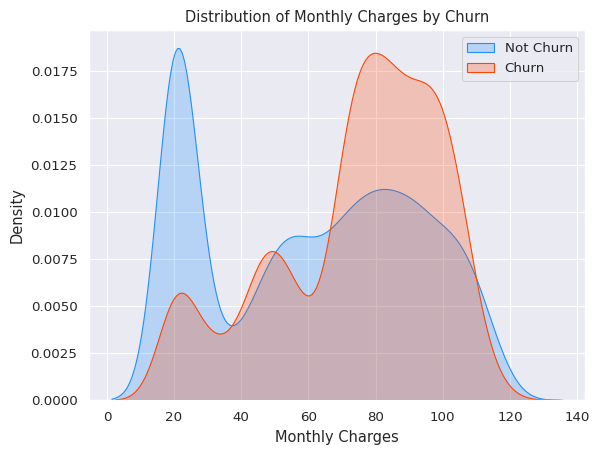

```python
# Set context for better visualization
sns.set_context("paper", font_scale=1.1)

# Create KDE plot with updated colors
ax = sns.kdeplot(df.MonthlyCharges[df["Churn"] == 'No'],
                 color="#1E90FF", shade=True)  # Dodger Blue for "Not Churn"
ax = sns.kdeplot(df.MonthlyCharges[df["Churn"] == 'Yes'],
                 ax=ax, color="#FF4500", shade=True)  # Orange Red for "Churn"

# Add legend and labels
ax.legend(["Not Churn", "Churn"], loc='upper right')
ax.set_ylabel('Density')
ax.set_xlabel('Monthly Charges')
ax.set_title('Distribution of Monthly Charges by Churn')

# Show plot
plt.show()
```

KDE plot shows the distribution of Total Charges for customers who churned (Tomato Red) vs. those who stayed (Steel Blue). It highlights that customers with lower total charges tend to churn more, while those with higher total charges are more likely to stay

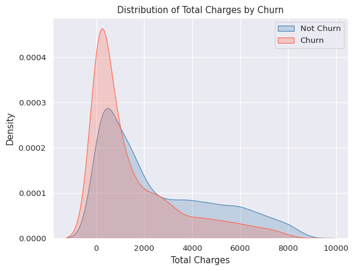

```python
# Create KDE plot with improved colors
ax = sns.kdeplot(df.TotalCharges[df["Churn"] == 'No'],
                 color="#4682B4", shade=True)  # Steel Blue for "Not Churn"
ax = sns.kdeplot(df.TotalCharges[df["Churn"] == 'Yes'],
                 ax=ax, color="#FF6347", shade=True)  # Tomato Red for "Churn"

# Corrected legend and improved readability
ax.legend(["Not Churn", "Churn"], loc='upper right')
ax.set_ylabel('Density')
ax.set_xlabel('Total Charges')
ax.set_title('Distribution of Total Charges by Churn')

# Show plot
plt.show()
```

Box plot visualizes the distribution of customer tenure for those who churned vs. stayed. It shows that customers with shorter tenures are more likely to churn, while those with longer tenures tend to stay also new customers are more likely to churn

```python
# Create a box plot to visualize tenure distribution for churned vs. non-churned customers
fig = px.box(df, x='Churn', y='tenure')

# Update y-axis properties (Labeling for better understanding)
fig.update_yaxes(title_text='Tenure (Months)', row=1, col=1)

# Update x-axis properties (Labeling the Churn categories)
fig.update_xaxes(title_text='Churn', row=1, col=1)

# Customize the layout with appropriate size and title
fig.update_layout(
    autosize=True,
    width=750,
    height=600,
    title_font=dict(size=25, family='Courier'),  # Set title font properties
    title='<b>Tenure vs Churn</b>',  # Bold title for better visibility
)

# Display the plot
fig.show()
```

[interactive chart not shown]

Below correlation heatmap visualizes relationships between different features in the dataset, with values ranging from -1 (strong negative correlation) to 1 (strong positive correlation). The upper triangle is masked to remove redundancy, making it easier to interpret key correlations.

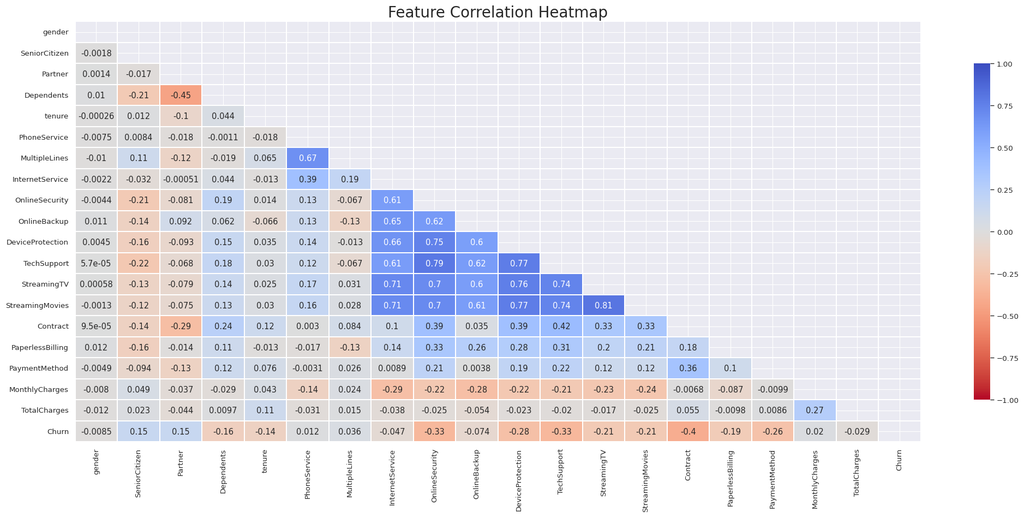

```python
# Set figure size for better readability
plt.figure(figsize=(25, 10))

# Compute correlation matrix (Convert categorical variables to numeric before correlation)
corr = df.apply(lambda x: pd.factorize(x)[0]).corr()

# Create an upper triangle mask to remove redundant values
mask = np.triu(np.ones_like(corr, dtype=bool))

# Generate heatmap with an improved color palette
ax = sns.heatmap(corr,
                 mask=mask,
                 xticklabels=corr.columns,
                 yticklabels=corr.columns,
                 annot=True,
                 linewidths=0.3,
                 cmap="coolwarm_r",  # Reversed 'coolwarm' for better contrast
                 vmin=-1,
                 vmax=1,
                 cbar_kws={'shrink': 0.8})  # Adjust color bar size

# Show plot
plt.title("Feature Correlation Heatmap", fontsize=20)
plt.show()
```

# Data Preprocessing

Function converts categorical (object) data into numerical labels using Label Encoding. It ensures that only columns with an 'object' dtype are transformed, making them suitable for machine learning models

```python
def object_to_int(dataframe_series):
    """
    Converts categorical (object) data into numerical values using Label Encoding.

    Parameters:
    dataframe_series (pd.Series): A column from a pandas DataFrame.

    Returns:
    pd.Series: Transformed series with integer labels if the data type is 'object'.
    """
    # Check if the column is of type 'object' (categorical)
    if dataframe_series.dtype == 'object':
        # Apply Label Encoding to convert categories into numeric values
        dataframe_series = LabelEncoder().fit_transform(dataframe_series)

    return dataframe_series

# Apply the object_to_int function to all columns in the DataFrame
df = df.apply(lambda x: object_to_int(x))

# Display the first few rows of the transformed DataFrame
df.head()
```

|  | gender | SeniorCitizen | Partner | Dependents | tenure | PhoneService | MultipleLines | InternetService | OnlineSecurity | OnlineBackup | DeviceProtection | TechSupport | StreamingTV | StreamingMovies | Contract | PaperlessBilling | PaymentMethod | MonthlyCharges | TotalCharges | Churn |
| --- | --- | --- | --- | --- | --- | --- | --- | --- | --- | --- | --- | --- | --- | --- | --- | --- | --- | --- | --- | --- |
| 0 | 0 | 0 | 1 | 0 | 1 | 0 | 1 | 0 | 0 | 2 | 0 | 0 | 0 | 0 | 0 | 1 | 2 | 29.85 | 29.85 | 0 |
| 1 | 1 | 0 | 0 | 0 | 34 | 1 | 0 | 0 | 2 | 0 | 2 | 0 | 0 | 0 | 1 | 0 | 3 | 56.95 | 1889.50 | 0 |
| 2 | 1 | 0 | 0 | 0 | 2 | 1 | 0 | 0 | 2 | 2 | 0 | 0 | 0 | 0 | 0 | 1 | 3 | 53.85 | 108.15 | 1 |
| 3 | 1 | 0 | 0 | 0 | 45 | 0 | 1 | 0 | 2 | 0 | 2 | 2 | 0 | 0 | 1 | 0 | 0 | 42.30 | 1840.75 | 0 |
| 4 | 0 | 0 | 0 | 0 | 2 | 1 | 0 | 1 | 0 | 0 | 0 | 0 | 0 | 0 | 0 | 1 | 2 | 70.70 | 151.65 | 1 |

Calculate and sort the correlation of all features with 'Churn', helping identify the most influential factors affecting customer churn. The sorted values allow for easy interpretation of which variables have the strongest positive or negative impact.

```python
# Set figure size for better visualization
plt.figure(figsize=(14, 7))

# Compute and display correlation of all features with 'Churn', sorted in descending order
df.corr()['Churn'].sort_values(ascending=False)
```

|  | Churn |
| --- | --- |
| Churn | 1.000000 |
| MonthlyCharges | 0.192858 |
| PaperlessBilling | 0.191454 |
| SeniorCitizen | 0.150541 |
| PaymentMethod | 0.107852 |
| MultipleLines | 0.038043 |
| PhoneService | 0.011691 |
| gender | -0.008545 |
| StreamingTV | -0.036303 |
| StreamingMovies | -0.038802 |
| InternetService | -0.047097 |
| Partner | -0.149982 |
| Dependents | -0.163128 |
| DeviceProtection | -0.177883 |
| OnlineBackup | -0.195290 |
| TotalCharges | -0.199484 |
| TechSupport | -0.282232 |
| OnlineSecurity | -0.289050 |
| tenure | -0.354049 |
| Contract | -0.396150 |

**dtype:** float64

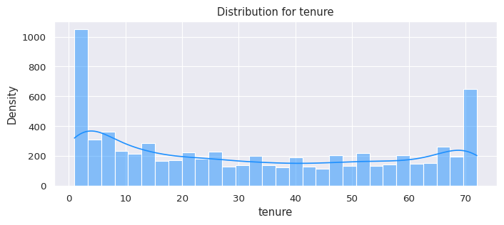

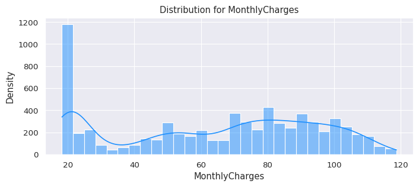

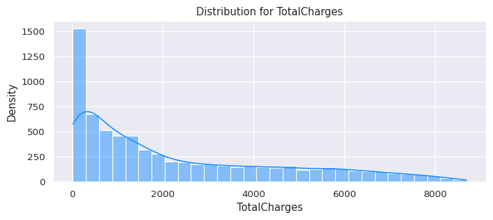

```python
# Separate the independent variables (features) by dropping the 'Churn' column
X = df.drop(columns=['Churn'])

# Extract the target variable (Churn) as a NumPy array for model training
y = df['Churn'].values

# Split the dataset into training (80%) and testing (20%) sets
X_train, X_test, y_train, y_test = train_test_split(
    X, y, test_size=0.20, random_state=40, stratify=y
)

def distplot(feature, frame, color='#1E90FF'):  # Using Dodger Blue for better visibility
    plt.figure(figsize=(8, 3))
    plt.title(f"Distribution for {feature}")

    # Improved distribution plot with modern Seaborn function
    sns.histplot(frame[feature], kde=True, color=color, bins=30)  # Histogram with KDE overlay

    plt.xlabel(feature)
    plt.ylabel("Density")
    plt.show()
# List of numerical columns to visualize
num_cols = ["tenure", "MonthlyCharges", "TotalCharges"]

# Loop through each numerical feature and plot its distribution
for feat in num_cols:
    distplot(feat, df)  # Call the distplot function for each column
```

Since the numerical features are distributed over different value ranges, I will use standard scalar to scale them down to the same range.

Standardize numerical columns (tenure, MonthlyCharges, and TotalCharges) using StandardScaler to bring them to a common scale. It then visualizes their distributions with distinct colors, helping to analyze their spread and detect patterns more clearly

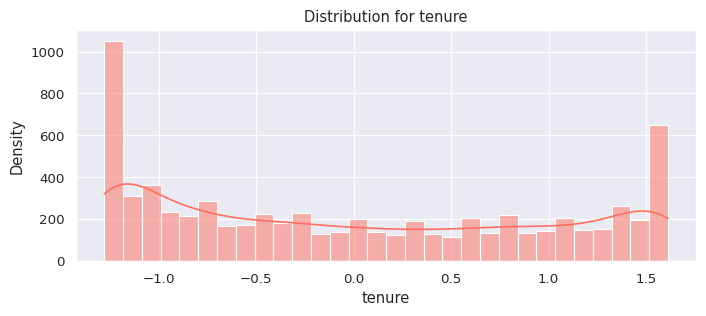

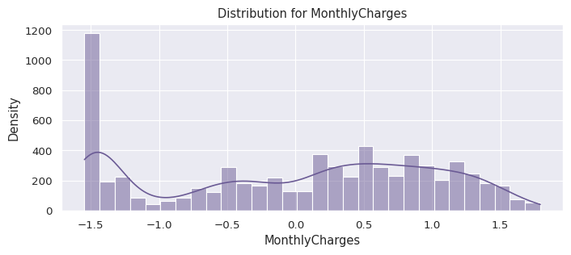

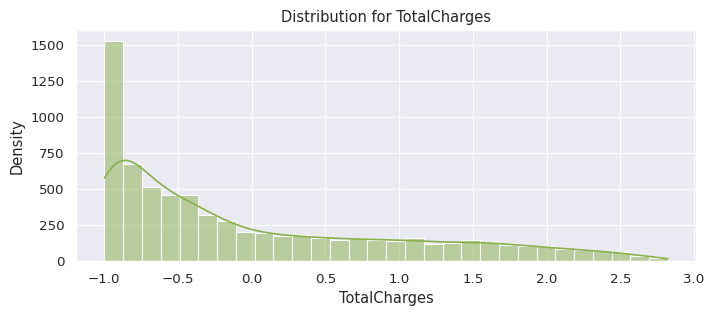

```python
# Standardize the numerical columns
df_std = pd.DataFrame(StandardScaler().fit_transform(df[num_cols].astype('float64')),
                       columns=num_cols)

# Loop through numerical features and plot distributions with distinct colors
colors = ['#FF6F61', '#6B5B95', '#88B04B']  # Coral, Deep Purple, Olive Green

for i, feat in enumerate(num_cols):
    distplot(feat, df_std, color=colors[i])  # Assigns a unique color to each plot
```

Categorize features into three groups: numerical columns for standardization, categorical columns for one-hot encoding (cat_cols_ohe), and categorical columns for label encoding (cat_cols_le). This ensures appropriate preprocessing for each data type, improving model performance and standardizes numerical features using StandardScaler, ensuring they have a mean of 0 and a standard deviation of 1. The scaler is fitted on X_train and then applied to both X_train and X_test, preventing data leakage

```python
# Columns that require **One-Hot Encoding** (categorical variables with multiple distinct categories)
cat_cols_ohe = ['PaymentMethod', 'Contract', 'InternetService']

# Columns that require **Label Encoding** (categorical variables with binary or ordinal values)
# This is determined by subtracting numerical and one-hot encoded columns from the total feature set
cat_cols_le = list(set(X_train.columns) - set(num_cols) - set(cat_cols_ohe))

# Initialize the StandardScaler
scaler = StandardScaler()

# Apply Standardization (Z-score normalization) on numerical columns
# Fit and transform on training data
X_train[num_cols] = scaler.fit_transform(X_train[num_cols])

# Transform test data using the same scaler (without refitting)
X_test[num_cols] = scaler.transform(X_test[num_cols])
```

# Machine Learning Model Evaluations and Predictions

Initialize a dictionary to store evaluation metrics (Precision, Recall, F1-Score, and AUC-ROC) for different machine learning models. It helps in systematically comparing model performance.

```python
# Initialize dictionaries to store the metrics
metrics = {
    "Model": [],
    "Precision": [],
    "Recall": [],
    "F1-Score": [],
    "AUC-ROC": []
}
```

**Logistic Regression**

Train a Logistic Regression model on the training dataset and evaluates its accuracy on the test set.

```python
# Logistic Regression model
logreg = LogisticRegression()
logreg.fit(X_train, y_train)

# Predictions
y_pred_logreg = logreg.predict(X_test)
y_pred_logreg_prob = logreg.predict_proba(X_test)[:, 1]  # For ROC-AUC score

# Evaluate the model
print("Logistic Regression Accuracy:", accuracy_score(y_test, y_pred_logreg))

# Calculate metrics
precision = precision_score(y_test, y_pred_logreg)
recall = recall_score(y_test, y_pred_logreg)
f1 = f1_score(y_test, y_pred_logreg)
auc_roc = roc_auc_score(y_test, y_pred_logreg_prob)

# Store the metrics
metrics["Model"].append("Logistic Regression")
metrics["Precision"].append(precision)
metrics["Recall"].append(recall)
metrics["F1-Score"].append(f1)
metrics["AUC-ROC"].append(auc_roc)

print(classification_report(y_test, y_pred_logreg))
```

```
Logistic Regression Accuracy: 0.8031272210376688
              precision    recall  f1-score   support

           0       0.85      0.89      0.87      1033
           1       0.65      0.56      0.60       374

    accuracy                           0.80      1407
   macro avg       0.75      0.73      0.74      1407
weighted avg       0.80      0.80      0.80      1407
```

Confusion matrix for a logistic regression model using a heatmap, helping to analyze model performance. It highlights true positives, true negatives, false positives, and false negatives for better evaluation.

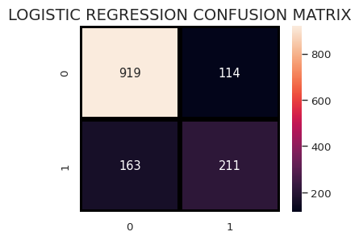

```python
# Set the figure size for better visualization
plt.figure(figsize=(4,3))

# Create and visualize the confusion matrix with a heatmap
sns.heatmap(confusion_matrix(y_test, y_pred_logreg),  # Compute confusion matrix
            annot=True,  # Display values inside cells
            fmt="d",  # Format numbers as integers
            linecolor="k",  # Set line color
            linewidths=3)  # Set line thickness between cells

# Add a title for better understanding
plt.title("LOGISTIC REGRESSION CONFUSION MATRIX", fontsize=14)

# Display the confusion matrix
plt.show()
```

Generate the ROC curve for a logistic regression model, showing the trade-off between True Positive Rate (TPR) and False Positive Rate (FPR). It helps assess the model’s classification performance, with a random baseline for comparison.

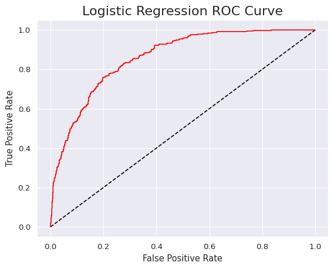

```python
# Predict probabilities for the positive class (Churn = Yes)
y_pred_prob = logreg.predict_proba(X_test)[:,1]

# Compute False Positive Rate (FPR), True Positive Rate (TPR), and thresholds
fpr, tpr, thresholds = roc_curve(y_test, y_pred_prob)

# Plot the ROC curve baseline (random model) as a dashed line
plt.plot([0, 1], [0, 1], 'k--', label="Random Model")

# Plot the actual ROC curve for Logistic Regression
plt.plot(fpr, tpr, label='Logistic Regression', color="r")

# Label the axes
plt.xlabel('False Positive Rate')
plt.ylabel('True Positive Rate')

# Add a title for clarity
plt.title('Logistic Regression ROC Curve', fontsize=16)

# Show the plot
plt.show()
```

**Decision Tree Classifier**

The Decision Tree Classifier model is trained on the dataset to predict customer churn. The model's accuracy is evaluated on test data, showing how well it classifies churn and non-churn customers.

```python
# Decision Tree model
dt = DecisionTreeClassifier(random_state=42)
dt.fit(X_train, y_train)

# Predictions
y_pred_dt = dt.predict(X_test)
y_pred_dt_prob = dt.predict_proba(X_test)[:, 1] # For ROC-AUC score

# Calculate metrics
precision = precision_score(y_test, y_pred_dt)
recall = recall_score(y_test, y_pred_dt)
f1 = f1_score(y_test, y_pred_dt)
auc_roc = roc_auc_score(y_test, y_pred_dt_prob)

# Store the metrics
metrics["Model"].append("Decision Tree")
metrics["Precision"].append(precision)
metrics["Recall"].append(recall)
metrics["F1-Score"].append(f1)
metrics["AUC-ROC"].append(auc_roc)

# Evaluate the model
print("Decision Tree Accuracy:", accuracy_score(y_test, y_pred_dt))
print(classification_report(y_test, y_pred_dt))
```

```
Decision Tree Accuracy: 0.7277896233120114
              precision    recall  f1-score   support

           0       0.82      0.81      0.81      1033
           1       0.49      0.51      0.50       374

    accuracy                           0.73      1407
   macro avg       0.65      0.66      0.66      1407
weighted avg       0.73      0.73      0.73      1407
```

The classification report for the Decision Tree model provides key performance metrics, including precision, recall, and F1-score for both churned and non-churned customers. It helps evaluate the model's ability to correctly identify churn cases while minimizing false positives and false negatives.

Perform hyperparameter tuning for the Decision Tree model using GridSearchCV, optimizing parameters like max_depth, min_samples_split, and min_samples_leaf to improve model performance. After selecting the best parameters, the tuned model is evaluated using accuracy and classification report to compare improvements over the baseline model.

```python
# Hyperparameter tuning using GridSearchCV
param_grid = {'max_depth': [5, 10, 15, 20], 'min_samples_split': [2, 5, 10],'min_samples_leaf': [1, 2, 4]}
grid_search = GridSearchCV(estimator=dt, param_grid=param_grid, cv=5)
grid_search.fit(X_train, y_train)

# Best parameters and model
print("Best parameters found:", grid_search.best_params_)
best_dt = grid_search.best_estimator_
y_pred_best_dt = best_dt.predict(X_test)

# Evaluate the tuned model
print("Tuned Decision Tree Accuracy:", accuracy_score(y_test, y_pred_best_dt))
print(classification_report(y_test, y_pred_best_dt))
```

```
Best parameters found: {'max_depth': 5, 'min_samples_leaf': 4, 'min_samples_split': 2}
Tuned Decision Tree Accuracy: 0.8059701492537313
              precision    recall  f1-score   support

           0       0.84      0.91      0.87      1033
           1       0.67      0.52      0.59       374

    accuracy                           0.81      1407
   macro avg       0.76      0.72      0.73      1407
weighted avg       0.80      0.81      0.80      1407
```

Compare the performance of Logistic Regression, Decision Tree, and Tuned Decision Tree models using the classification report, which includes Precision, Recall, F1-Score, and Accuracy. It helps evaluate and select the best-performing model.

```python
# Comparison of the models' performance
print("Logistic Regression Performance:")
print(classification_report(y_test, y_pred_logreg))

print("Decision Tree Performance:")
print(classification_report(y_test, y_pred_dt))

print("Tuned Decision Tree Performance:")
print(classification_report(y_test, y_pred_best_dt))
```

```
Logistic Regression Performance:
              precision    recall  f1-score   support

           0       0.85      0.89      0.87      1033
           1       0.65      0.56      0.60       374

    accuracy                           0.80      1407
   macro avg       0.75      0.73      0.74      1407
weighted avg       0.80      0.80      0.80      1407

Decision Tree Performance:
              precision    recall  f1-score   support

           0       0.82      0.81      0.81      1033
           1       0.49      0.51      0.50       374

    accuracy                           0.73      1407
   macro avg       0.65      0.66      0.66      1407
weighted avg       0.73      0.73      0.73      1407

Tuned Decision Tree Performance:
              precision    recall  f1-score   support

           0       0.84      0.91      0.87      1033
           1       0.67      0.52      0.59       374

    accuracy                           0.81      1407
   macro avg       0.76      0.72      0.73      1407
weighted avg       0.80      0.81      0.80      1407
```

Extract precision, recall, and F1-score from classification reports and visualizes the performance of Logistic Regression, Decision Tree, and Tuned Decision Tree models using a bar chart. It helps compare model effectiveness across key evaluation metrics.

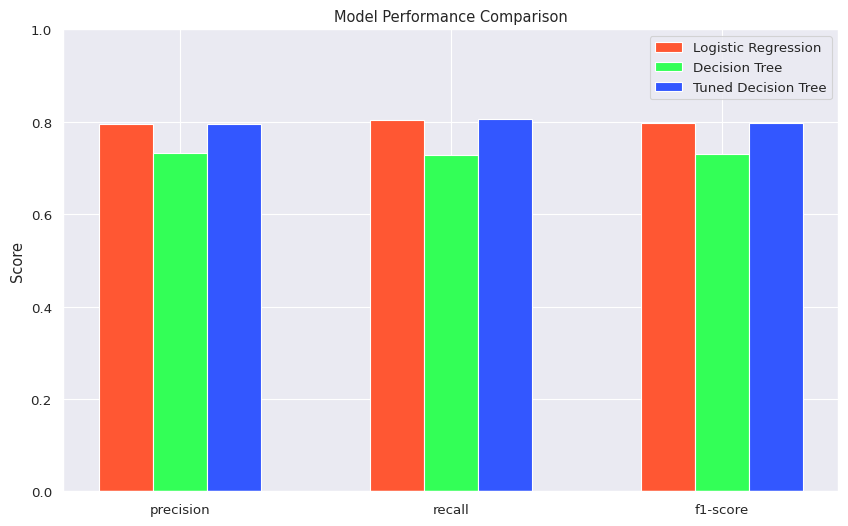

```python
# Extract classification reports as dictionaries
lr_report = classification_report(y_test, y_pred_logreg, output_dict=True)
dt_report = classification_report(y_test, y_pred_dt, output_dict=True)
tuned_dt_report = classification_report(y_test, y_pred_best_dt, output_dict=True)

# Metrics to compare
comparion_metrics = ['precision', 'recall', 'f1-score']

# Model names
models = ['Logistic Regression', 'Decision Tree', 'Tuned Decision Tree']

# Extract weighted average scores for each metric
lr_scores = [lr_report['weighted avg'][metric] for metric in comparion_metrics]
dt_scores = [dt_report['weighted avg'][metric] for metric in comparion_metrics]
tuned_dt_scores = [tuned_dt_report['weighted avg'][metric] for metric in comparion_metrics]

# Bar width and positions
bar_width = 0.2
x = np.arange(len(comparion_metrics))

# Plot bars
plt.figure(figsize=(10, 6))
plt.bar(x - bar_width, lr_scores, bar_width, label='Logistic Regression', color='#FF5733')
plt.bar(x, dt_scores, bar_width, label='Decision Tree', color='#33FF57')
plt.bar(x + bar_width, tuned_dt_scores, bar_width, label='Tuned Decision Tree', color='#3357FF')

# Labels and title
plt.xticks(ticks=x, labels=comparion_metrics)
plt.ylabel('Score')
plt.title('Model Performance Comparison')
plt.legend()
plt.ylim(0, 1)

# Show plot
plt.show()
```

**Model Performance comparison**

Best Model After Comparison: **Tuned Decision Tree**

Comparison Highlights:

**1.Highest Accuracy:** Tuned Decision Tree: 81%

Logistic Regression: 80%

Default Decision Tree: 73% (Lowest)

**2.Better Recall for Churners**

Logistic Regression: 56% (Best for recall)

Tuned Decision Tree: 52%

Default Decision Tree: 51%

**3.Balanced Precision and F1-Score:**

Tuned Decision Tree: Precision (67%), F1-Score (59%)

Logistic Regression: Precision (65%), F1-Score (60%)

Default Decision Tree: Precision (49%), F1-Score (50%) (Worst)

**The Tuned Decision Tree is the best model** as it achieves the highest accuracy (81%), maintains a good balance between precision and recall, and outperforms the default Decision Tree significantly

**Random Forest Classifier**

A Random Forest Classifier with 100 decision trees and trains it on the dataset and fit to enable the model to learn patterns from the training data for classification.

```python
# Initialize the Random Forest Classifier
rf = RandomForestClassifier(n_estimators=100, random_state=42)

# Train the model
rf.fit(X_train, y_train)
```

```
RandomForestClassifier(random_state=42)
```

perform Grid Search Cross-Validation to find the optimal hyperparameters for a Random Forest Classifier by testing different combinations. It selects the best model based on performance, ensuring improved accuracy and efficiency.

```python
# Define the parameter grid
param_grid = {
    'n_estimators': [50, 100, 150],
    'max_depth': [10, 20, 30],
    'min_samples_split': [2, 5, 10],
    'min_samples_leaf': [1, 2, 4]
}

# Perform Grid Search
grid_search = GridSearchCV(estimator=rf, param_grid=param_grid, cv=5, n_jobs=-1, verbose=2)
grid_search.fit(X_train, y_train)

# Get the best parameters from GridSearchCV
print("Best Hyperparameters: ", grid_search.best_params_)

# Use the best model from grid search
best_rf = grid_search.best_estimator_
```

```
Fitting 5 folds for each of 81 candidates, totalling 405 fits
Best Hyperparameters:  {'max_depth': 20, 'min_samples_leaf': 4, 'min_samples_split': 2, 'n_estimators': 100}
```

Make predictions using the best-tuned Random Forest model, calculates key evaluation metrics (Precision, Recall, F1-Score, AUC-ROC, and Accuracy), and stores them for comparison. Also print the classification report and ROC-AUC score to assess model performance.

```python
# Predictions
y_pred_rf = best_rf.predict(X_test)
y_prob_rf = best_rf.predict_proba(X_test)[:, 1]# For ROC-AUC score

# Calculate metrics
precision = precision_score(y_test, y_pred_rf)
recall = recall_score(y_test, y_pred_rf)
f1 = f1_score(y_test, y_pred_rf)
auc_roc = roc_auc_score(y_test, y_prob_rf)

# Store the metrics
metrics["Model"].append("Random Forest")
metrics["Precision"].append(precision)
metrics["Recall"].append(recall)
metrics["F1-Score"].append(f1)
metrics["AUC-ROC"].append(auc_roc)

# Accuracy score
accuracy = accuracy_score(y_test, y_pred_rf)
print(f'Accuracy: {accuracy:.4f}')

# Classification Report
print("Classification Report:")
print(classification_report(y_test, y_pred_rf))

# ROC-AUC Score
roc_auc = roc_auc_score(y_test, y_prob_rf)
print(f'ROC-AUC Score: {roc_auc:.4f}')
```

```
Accuracy: 0.8053
Classification Report:
              precision    recall  f1-score   support

           0       0.84      0.91      0.87      1033
           1       0.67      0.52      0.59       374

    accuracy                           0.81      1407
   macro avg       0.76      0.71      0.73      1407
weighted avg       0.80      0.81      0.80      1407

ROC-AUC Score: 0.8566
```

Visualize the confusion matrix for the Random Forest model using a heatmap, showing the counts of true positives, true negatives, false positives, and false negatives. It helps in understanding model performance and misclassification patterns.

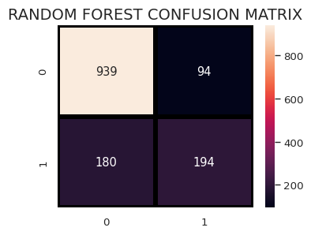

```python
# Set figure size for better readability
plt.figure(figsize=(4,3))

# Generate a heatmap to visualize the confusion matrix of the Random Forest model
sns.heatmap(confusion_matrix(y_test, y_pred_rf),
            annot=True,  # Display numerical values in the heatmap
            fmt="d",      # Format values as integers
            linecolor="k", # Set line color to black
            linewidths=3)  # Set line width for clear separation

# Set the title of the heatmap
plt.title("RANDOM FOREST CONFUSION MATRIX", fontsize=14)

# Display the plot
plt.show()
```

plot the ROC curve for the Random Forest model, showing the trade-off between True Positive Rate (TPR) and False Positive Rate (FPR). It helps evaluate the model’s ability to distinguish between classes, with a random baseline for comparison.

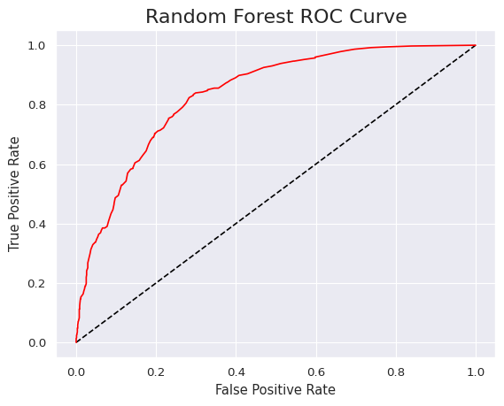

```python
# Predict probabilities for the positive class (Churn = Yes) using the Random Forest model
y_rfpred_prob = rf.predict_proba(X_test)[:, 1]

# Compute False Positive Rate (FPR), True Positive Rate (TPR), and thresholds for ROC Curve
fpr_rf, tpr_rf, thresholds = roc_curve(y_test, y_rfpred_prob)

# Plot the baseline for a random model (diagonal line)
plt.plot([0, 1], [0, 1], 'k--', label="Random Model")

# Plot the actual ROC curve for the Random Forest model
plt.plot(fpr_rf, tpr_rf, label='Random Forest', color="r")

# Label the axes
plt.xlabel('False Positive Rate')
plt.ylabel('True Positive Rate')

# Add a title for clarity
plt.title('Random Forest ROC Curve', fontsize=16)

# Display the plot
plt.show()
```

Extract and visualize the feature importance from the best-tuned Random Forest model, helping identify which features contribute most to predictions. The bar plot ranks features by importance, aiding in feature selection and model interpretation

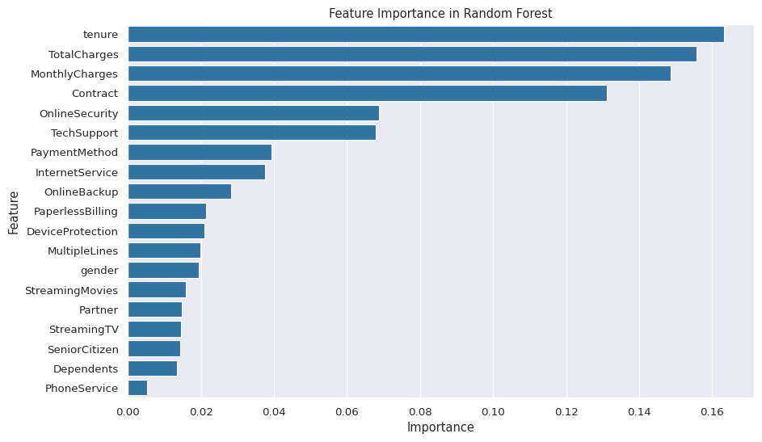

```python
# Get feature importance
feature_importances = best_rf.feature_importances_

# Create a DataFrame for better visualization
feature_df = pd.DataFrame({'Feature': X.columns, 'Importance': feature_importances})
feature_df = feature_df.sort_values(by='Importance', ascending=False)

# Plot feature importance
plt.figure(figsize=(10, 6))
sns.barplot(x='Importance', y='Feature', data=feature_df)
plt.title('Feature Importance in Random Forest')
plt.show()
```

**KNN model**

Initialize a K-Nearest Neighbors (KNN) classifier with k=5, meaning the model considers the 5 closest neighbors to classify a data point. It then trains the model on the dataset using the fit() method.

```python
# Initialize the KNN model with k=5
knn = KNeighborsClassifier(n_neighbors=5)

# Train the model
knn.fit(X_train, y_train)
```

```
KNeighborsClassifier()
```

Perform Grid Search Cross-Validation to find the optimal value of k for the K-Nearest Neighbors (KNN) model, testing different values to improve accuracy. It then selects and stores the best-performing KNN model for further evaluation.

```python
# Define the parameter grid for k
param_grid = {'n_neighbors': [3, 5, 7, 10, 15, 20]}

# Perform Grid Search with cross-validation
grid_search = GridSearchCV(KNeighborsClassifier(), param_grid, cv=5)
grid_search.fit(X_train, y_train)

# Get the best value for k
print("Best k:", grid_search.best_params_)

# Use the best KNN model from grid search
best_knn = grid_search.best_estimator_
```

```
Best k: {'n_neighbors': 20}
```

Evaluate the best K-Nearest Neighbors (KNN) model by making predictions and calculating key performance metrics (Precision, Recall, F1-Score, AUC-ROC, and Accuracy). It then prints the classification report and ROC-AUC score to assess the model’s effectiveness.

```python
# Predictions
y_pred_knn = best_knn.predict(X_test)
y_prob_knn = best_knn.predict_proba(X_test)[:, 1]  # For ROC-AUC score

# Calculate metrics
precision = precision_score(y_test, y_pred_knn)
recall = recall_score(y_test, y_pred_knn)
f1 = f1_score(y_test, y_pred_knn)
auc_roc = roc_auc_score(y_test, y_prob_knn)

# Store the metrics
metrics["Model"].append("K-Nearest Neighbour")
metrics["Precision"].append(precision)
metrics["Recall"].append(recall)
metrics["F1-Score"].append(f1)
metrics["AUC-ROC"].append(auc_roc)

# Accuracy score
accuracy = accuracy_score(y_test, y_pred_knn)
print(f'Accuracy: {accuracy:.4f}')

# Classification Report
print("Classification Report:")
print(classification_report(y_test, y_pred_knn))

# ROC-AUC Score
roc_auc = roc_auc_score(y_test, y_prob_knn)
print(f'ROC-AUC Score: {roc_auc:.4f}')
```

```
Accuracy: 0.7868
Classification Report:
              precision    recall  f1-score   support

           0       0.83      0.89      0.86      1033
           1       0.63      0.49      0.55       374

    accuracy                           0.79      1407
   macro avg       0.73      0.69      0.71      1407
weighted avg       0.78      0.79      0.78      1407

ROC-AUC Score: 0.8261
```

Test different K values for the K-Nearest Neighbors (KNN) model, measuring accuracy for each to find the optimal k. The plotted graph helps visualize how k affects model accuracy, guiding the best choice for classification.

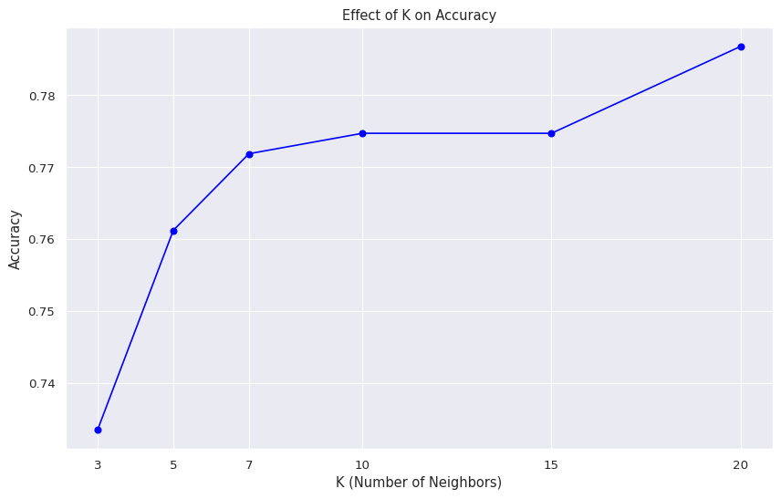

```python
# Try different values of k
k_values = [3, 5, 7, 10, 15, 20]
accuracies = []

for k in k_values:
    knn = KNeighborsClassifier(n_neighbors=k)
    knn.fit(X_train, y_train)
    y_pred = knn.predict(X_test)
    accuracies.append(accuracy_score(y_test, y_pred))

# Plot the accuracies for different k values
plt.figure(figsize=(10, 6))
plt.plot(k_values, accuracies, marker='o', color='b')
plt.title('Effect of K on Accuracy')
plt.xlabel('K (Number of Neighbors)')
plt.ylabel('Accuracy')
plt.xticks(k_values)
plt.grid(True)
plt.show()
```

Convert the model evaluation metrics (Precision, Recall, F1-Score, and AUC-ROC) into a Pandas DataFrame for better visualization and comparison across different models. It then prints the results for analysis.

```python
# Convert results to DataFrame
results_df = pd.DataFrame(metrics)
print(results_df)
```

```
                 Model  Precision    Recall  F1-Score   AUC-ROC
0  Logistic Regression   0.649231  0.564171  0.603720  0.860220
1        Decision Tree   0.488550  0.513369  0.500652  0.660238
2        Random Forest   0.673611  0.518717  0.586103  0.856591
3  K-Nearest Neighbour   0.625850  0.491979  0.550898  0.826144
```

Create a bar chart to compare different models based on Precision, Recall, F1-Score, and AUC-ROC, helping visualize performance differences. The comparison plot aids in selecting the best model for classification.

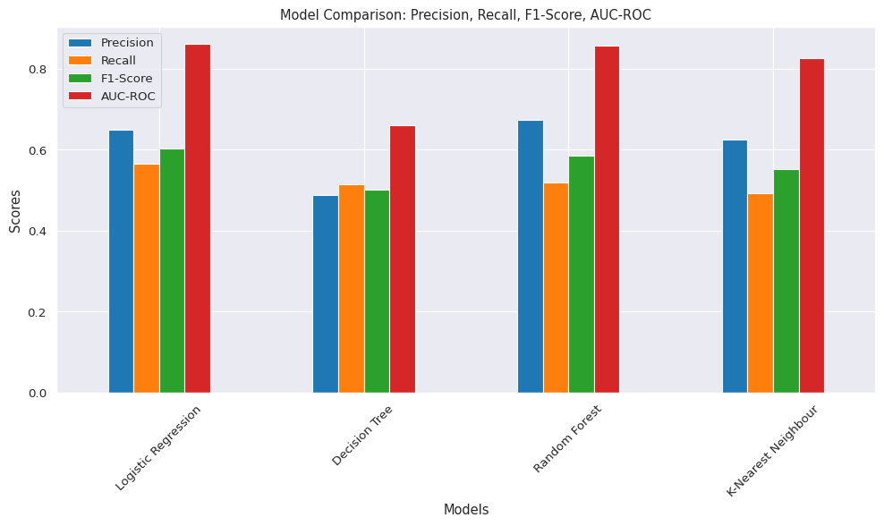

```python
# 7. Plot the comparison chart
plt.figure(figsize=(10, 6))
results_df.set_index('Model').plot(kind='bar', figsize=(10, 6))
plt.title('Model Comparison: Precision, Recall, F1-Score, AUC-ROC')
plt.ylabel('Scores')
plt.xlabel('Models')
plt.xticks(rotation=45)
plt.tight_layout()
plt.show()
```

# Best Model Evaluation

Based on the provided performance metrics, **Logistic Regression** is the best model.

1.It has the **highest F1-score (0.6037)**, indicating a good balance between **precision and recall**.

2.It also has the **highest AUC-ROC (0.8602)**, meaning it is the best at distinguishing between churn and non-churn customers.

Logistic Regression is the most effective model in this comparison